# Project two: Analytics of Global Warming Tweets on January 2023.

This proejct is based on global warming tweets tweeted on January 2023. I have added emotion (anger, joy, opotimism and sadness) and gender at the end of each tweets. Emotion analysis was performed using a pre-trained model from Hugging Face (Twitter-roBERTa-base for Emotion Recognition). This is a roBERTa-base model trained on ~58M tweets and finetuned for emotion recognition with the TweetEval benchmark. Each tweet is classified into four emotions (joy, optimism, anger, and sadness) with a confidence score. In addition, gender was extracted based on first name of user account if a user account has a real first name and the gender can be identified by python package gender guesser.

Please develop 10 questions you want to investiage based on your interest, use both pyspark and SQL to answer each questions and visualiz your results. Please check my attached research paper for possible analysis you can conduct. This paper won the best paper award in a recent conference of Northeast Decision Science Institute.

```python
from pyspark.sql import SparkSession
import pyspark.sql.functions as F
from helper_functions import displayByGroup
import os
import pandas as pd
import seaborn as sns
import matplotlib.pyplot as plt

# check if the Spark session is active. If it is activate, close it

try:
    if spark:
        spark.stop()
except:
    pass

spark = (SparkSession.builder.appName("Multidimensional Data Frame")
        .config("spark.port.maxRetries", "100")
        .config("spark.sql.mapKeyDedupPolicy", "LAST_WIN")  # This configuration allow the duplicate keys in the map data type.
#        .config("spark.driver.memory", "16g")
        .getOrCreate())

# confiture the log level (defaulty is WWARN)
spark.sparkContext.setLogLevel('ERROR')

# read the global warming tweets

df=spark.read.parquet('/opt/shared/globalwarming_202301')
```

[output not shown]

[output cut: 24 more lines]

[output not shown]

```python
df.select('author').printSchema()
```

## 1. How many people are tweeting in the United States and Canada (based on the lists that I created) (Spark)?

```python
nalist ={'USA':'USA','United States of America':'USA', 'United States':'USA',
         'UNITED STATES OF AMERICA':'USA','UNITED STATES':'USA','usa':'USA',
        'CANADA':'CAN','canada':'CAN', 'can':'CAN','CAN':'CAN'}
```

```python
nalist1=['canada','CANADA','can','CAN','USA','usa','United States','UNITED STATES','United States of America','UNITED STATES OF AMERICA']
```

```python
df1=df.select('author.location', F.col('author.location').alias('locations')).filter(F.col('locations').isNotNull())


df2=df1.filter(df1["locations"].isin(nalist1))
naloc=df2.groupby('locations').count().toPandas()
```

```python
naloc.head(5)
```

|  | locations | count |
| --- | --- | --- |
| 0 | CANADA | 20 |
| 1 | United States | 4064 |
| 2 | canada | 30 |
| 3 | USA | 2543 |
| 4 | United States of America | 135 |

```python
naloc['locations'] = naloc['locations'].replace(nalist)
```

```python
naloc.head(5)
```

|  | locations | count |
| --- | --- | --- |
| 0 | CAN | 20 |
| 1 | USA | 4064 |
| 2 | CAN | 30 |
| 3 | USA | 2543 |
| 4 | USA | 135 |

```python
locNA=naloc.groupby('locations', as_index=False)['count'].sum()
locNA.head()
```

|  | locations | count |
| --- | --- | --- |
| 0 | CAN | 50 |
| 1 | USA | 6783 |

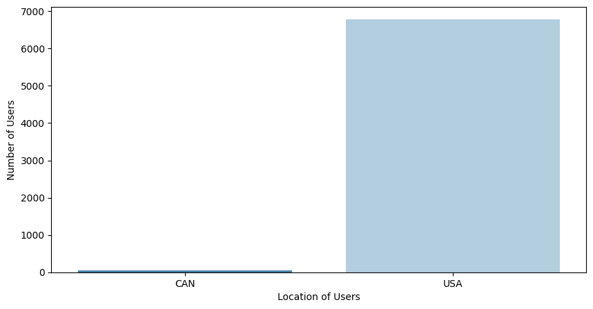

```python
plt.figure(figsize=(10 ,5))

usacan = sns.barplot(data=locNA, y='count',x="locations", orient='v', palette='Blues_r')

usacan.set_xlabel( "Location of Users")
usacan.set_ylabel( "Number of Users")
```

Using my lists that I created above I found that there are 50 users that tweeted in Canada and 6783 who tweeted in the USA. This number is based on those who used the country name or abbreviation in their bio. Therefore the true accuracy is different from this and would take much longer for me to figure out.

## 2. How many verified users are there? (Spark and Spark SQL)

```python
df.select('author.verified').printSchema()
```

```
root
 |-- verified: boolean (nullable = true)
```

```python
df.select('author.verified').show(10)
```

```
+--------+
|verified|
+--------+
|   false|
|   false|
|   false|
|    true|
|   false|
|   false|
|   false|
|   false|
|   false|
|   false|
+--------+
only showing top 10 rows
```

```python
df.groupby('author.verified').count().show(10)
```

```
[Stage 132:============>                                         (15 + 49) / 64]
```

```
+--------+------+
|verified| count|
+--------+------+
|    true| 18451|
|   false|326416|
+--------+------+
```

```python
ver=df.groupby('author.verified').count().toPandas()
ver.head()
```

|  | verified | count |
| --- | --- | --- |
| 0 | True | 18451 |
| 1 | False | 326416 |

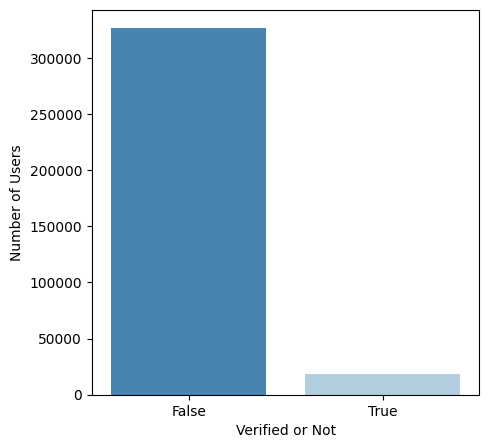

```python
plt.figure(figsize=(5 ,5))

verif = sns.barplot(data=ver, y='count',x="verified", orient='v', palette='Blues_r')

verif.set_xlabel( "Verified or Not")
verif.set_ylabel( "Number of Users")
```

```python
selected_columns=['author.username', 'author.verified']


Verif=df.select(selected_columns)

Verif.createOrReplaceTempView("verified_t")
```

```python
verifcount= spark.sql(
    """SELECT
            verified,
            COUNT(*) AS count
        FROM verified_t
        GROUP BY verified
        """
).toPandas()
verifcount.head()
```

|  | verified | count |
| --- | --- | --- |
| 0 | True | 18451 |
| 1 | False | 326416 |

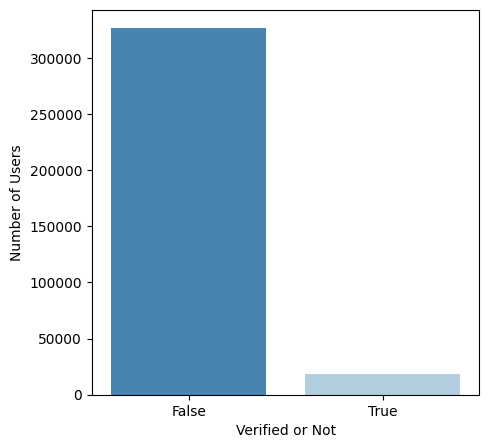

```python
plt.figure(figsize=(5 ,5))

verif1 = sns.barplot(data=verifcount, y='count',x="verified", orient='v', palette='Blues_r')

verif1.set_xlabel( "Verified or Not")
verif1.set_ylabel( "Number of Users")
```

There are 326416 users that are not verified compared to on 18451 users that are verified!

## 3. What are the top 5 users based on number of followers? (Spark and SQL)

```python
df.select('author.public_metrics.followers_count').printSchema()
```

```
root
 |-- followers_count: long (nullable = true)
```

```python
df1=df.select('author.username','author.public_metrics.followers_count')\
.orderBy(F.desc('followers_count'))
followers=df1.limit(10).toPandas()
```

```python
followers.head(10)
```

|  | username | followers_count |
| --- | --- | --- |
| 0 | elonmusk | 137099017 |
| 1 | NASA | 72837185 |
| 2 | CNN | 61370413 |
| 3 | CNN | 61367945 |
| 4 | nytimes | 55097762 |
| 5 | nytimes | 55097746 |
| 6 | BBCWorld | 39781378 |
| 7 | TheEconomist | 27202727 |
| 8 | TheEconomist | 27202710 |
| 9 | TheEconomist | 27202622 |

```python
followers1=followers.drop_duplicates(subset='username')
followers1.head(6)
```

|  | username | followers_count |
| --- | --- | --- |
| 0 | elonmusk | 137099017 |
| 1 | NASA | 72837185 |
| 2 | CNN | 61370413 |
| 4 | nytimes | 55097762 |
| 6 | BBCWorld | 39781378 |
| 7 | TheEconomist | 27202727 |

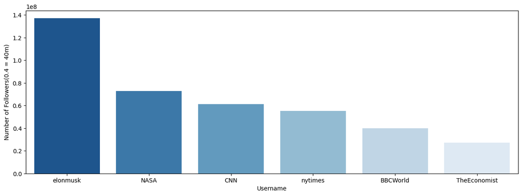

```python
plt.figure(figsize=(15 ,5))

followersgraph = sns.barplot(data=followers1, y='followers_count',x="username", orient='v', palette='Blues_r')

followersgraph.set_xlabel( "Username")
followersgraph.set_ylabel( "Number of Followers(0.4 = 40m)")
```

```python
selected_columns=['author.username',
 'author.public_metrics.followers_count',
 'author.public_metrics.following_count',
 'author.public_metrics.tweet_count',
 'author.public_metrics.listed_count']


usercounts=df.select(selected_columns)

usercounts.createOrReplaceTempView("usercounts_t")
```

```python
followercount= spark.sql(
    """SELECT DISTINCT
            username,
            followers_count
        FROM usercounts_t
        ORDER BY followers_count DESC
        LIMIT 10
        """
)
followercount.createOrReplaceTempView('followercount')
```

```python
numFollowers=spark.sql(
    """ SELECT
        username,
        MAX(followers_count)
    FROM followercount
    GROUP BY username
    """
).toPandas()
numFollowers.head()
```

|  | username | max(followers_count) |
| --- | --- | --- |
| 0 | elonmusk | 137099017 |
| 1 | NASA | 72837185 |
| 2 | CNN | 61370413 |
| 3 | nytimes | 55097762 |
| 4 | BBCWorld | 39781378 |

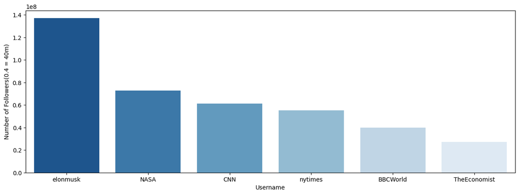

```python
plt.figure(figsize=(15 ,5))

followersgraph1 = sns.barplot(data=numFollowers, y='max(followers_count)',x="username", orient='v', palette='Blues_r')

followersgraph1.set_xlabel( "Username")
followersgraph1.set_ylabel( "Number of Followers(0.4 = 40m)")
```

The people with the highest number of followers that tweeted about global warming are Elon Musk, NASA, CNN, New York Times, BBC World (News), and The Economist. This makes sense because they are all verified acocunts and they all are very well known all over the world.

## 4. What are the top 5 users based on the number people they are following? (Spark and SQL)

```python
df.select('author.public_metrics.following_count').printSchema()
```

```
root
 |-- following_count: long (nullable = true)
```

```python
df1=df.select('author.username','author.public_metrics.following_count')\
.orderBy(F.desc('following_count'))
following=df1.limit(6).toPandas()
```

```python
following.head(10)
```

|  | username | following_count |
| --- | --- | --- |
| 0 | jilevin | 612022 |
| 1 | CordeiroRick | 558065 |
| 2 | CordeiroRick | 558065 |
| 3 | PAMsLOvE | 534854 |
| 4 | RareCat | 477125 |
| 5 | iownjd | 438931 |

```python
following1=following.drop_duplicates(subset='username')
following1.head()
```

|  | username | following_count |
| --- | --- | --- |
| 0 | jilevin | 612022 |
| 1 | CordeiroRick | 558065 |
| 3 | PAMsLOvE | 534854 |
| 4 | RareCat | 477125 |
| 5 | iownjd | 438931 |

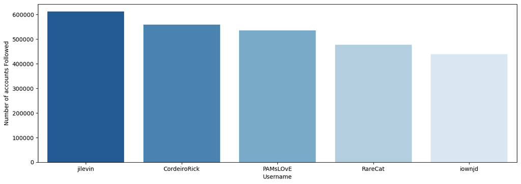

```python
plt.figure(figsize=(15 ,5))

followinggraph = sns.barplot(data=following1, y='following_count',x="username", orient='v', palette='Blues_r')

followinggraph.set_xlabel( "Username")
followinggraph.set_ylabel( "Number of accounts Followed")
```

```python
selected_columns=['author.username',
 'author.public_metrics.followers_count',
 'author.public_metrics.following_count',
 'author.public_metrics.tweet_count',
 'author.public_metrics.listed_count']


usercounts=df.select(selected_columns)

usercounts.createOrReplaceTempView("usercounts_t")
```

```python
followingcount= spark.sql(
    """SELECT DISTINCT
            username,
            following_count
        FROM usercounts_t
        ORDER BY following_count DESC
        LIMIT 5
        """
)
followingcount.createOrReplaceTempView('followingcount')
```

```python
numFollowing=spark.sql(
    """ SELECT
        username,
        MAX(following_count)
    FROM followingcount
    GROUP BY username
    """
).toPandas()
numFollowing.head()
```

|  | username | max(following_count) |
| --- | --- | --- |
| 0 | jilevin | 612022 |
| 1 | CordeiroRick | 558065 |
| 2 | PAMsLOvE | 534854 |
| 3 | RareCat | 477125 |
| 4 | iownjd | 438931 |

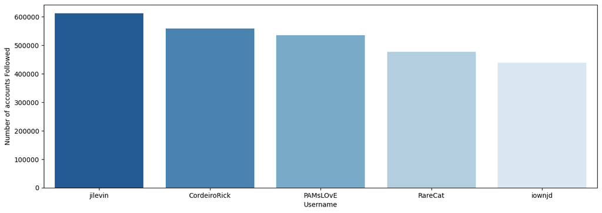

```python
plt.figure(figsize=(15 ,5))

followinggraph1 = sns.barplot(data=numFollowing, y='max(following_count)',x="username", orient='v', palette='Blues_r')

followinggraph1.set_xlabel( "Username")
followinggraph1.set_ylabel( "Number of accounts Followed")
```

These are the users that tweet about global warming who follow the most amount of people. I was curious to see if there would be anyone noteable here and there was not.

## 5. Who are the top 10 users by number of tweets? (Spark and Spark SQL)

```python
df.select('author.public_metrics.tweet_count').printSchema()
```

```
root
 |-- tweet_count: long (nullable = true)
```

```python
df1=df.select('author.username','author.public_metrics.tweet_count')\
.orderBy(F.desc('tweet_count'))
twts=df1.limit(24).toPandas()
```

```python
twts.head()
```

|  | username | tweet_count |
| --- | --- | --- |
| 0 | wywvwyw | 7223844 |
| 1 | wywvwyw | 7223844 |
| 2 | soldier_777 | 4488686 |
| 3 | OccuWorld | 3674417 |
| 4 | OccuWorld | 3674417 |

```python
twts1=twts.drop_duplicates(subset='username')
twts1.head()
```

|  | username | tweet_count |
| --- | --- | --- |
| 0 | wywvwyw | 7223844 |
| 2 | soldier_777 | 4488686 |
| 3 | OccuWorld | 3674417 |
| 5 | missb62 | 3226546 |
| 8 | marekingu | 3143724 |

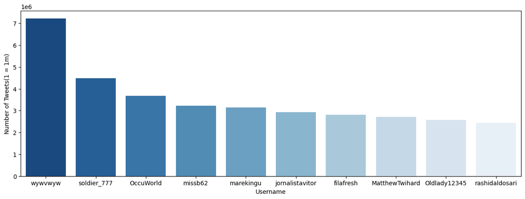

```python
plt.figure(figsize=(15 ,5))

twtsgraph = sns.barplot(data=twts1, y='tweet_count',x="username", orient='v', palette='Blues_r')

twtsgraph.set_xlabel( "Username")
twtsgraph.set_ylabel( "Number of Tweets(1 = 1m)")
```

```python
selected_columns=['author.username',
 'author.public_metrics.followers_count',
 'author.public_metrics.following_count',
 'author.public_metrics.tweet_count',
 'author.public_metrics.listed_count']


usercounts=df.select(selected_columns)

usercounts.createOrReplaceTempView("usercounts_t")
```

```python
tweetcount= spark.sql(
    """SELECT DISTINCT
            username,
            tweet_count
        FROM usercounts_t
        ORDER BY tweet_count DESC
        LIMIT 15
        """
)
tweetcount.createOrReplaceTempView('tweetcount')
```

```python
numTweets=spark.sql(
    """ SELECT
        username,
        MAX(tweet_count)
    FROM tweetcount
    GROUP BY username
    """
).toPandas()
numTweets.head()
```

|  | username | max(tweet_count) |
| --- | --- | --- |
| 0 | wywvwyw | 7223844 |
| 1 | soldier_777 | 4488686 |
| 2 | OccuWorld | 3674417 |
| 3 | missb62 | 3226546 |
| 4 | marekingu | 3143724 |

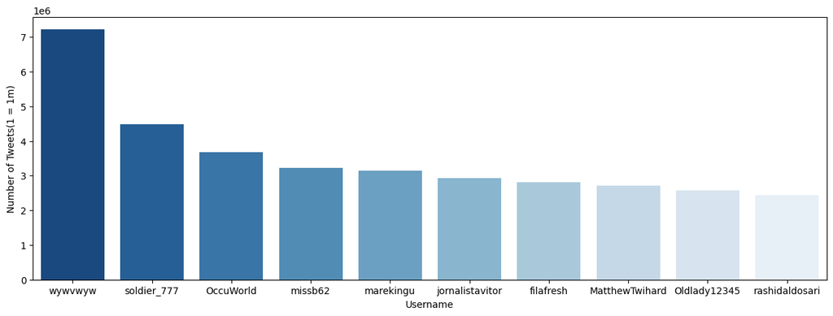

```python
plt.figure(figsize=(15 ,5))

twtsgraph1 = sns.barplot(data=numTweets, y='max(tweet_count)',x="username", orient='v', palette='Blues_r')

twtsgraph1.set_xlabel( "Username")
twtsgraph1.set_ylabel( "Number of Tweets(1 = 1m)")
```

Shown are the top 10 users based on the number of tweets.

## 6. What are the top 10 Hashtags? (Spark)

```python
df1=df.select('author.username','entities.hashtags.tag')
df1.show()
```

```
+---------------+--------------------+
|       username|                 tag|
+---------------+--------------------+
|    energylevel|                null|
|        JoAmsel|                null|
|   stevieb_6262|                null|
| HillThePropNut|                null|
| OscurPanderton|                null|
|   joecal198824|                null|
|notrushbaby78v2|[GretaThunberg, G...|
|   SafariJohn19|                null|
|    3beebeebee3|                null|
|    CA_22562_AN|                null|
|      Maddman60|                null|
|        fladdle|                null|
|   EDITORatWORK|[climate, change,...|
|       NaMarais|                null|
|       s_ofia_1|                null|
|        dawphin|                null|
|  Kitos_the_fox|                null|
| A_Username2112|                null|
|greenbananajohn|                null|
|   LMAO16640556|                null|
+---------------+--------------------+
only showing top 20 rows
```

```python
df2=df1.filter(df1['tag'].isNotNull())
```

```python
df2.show()
```

```
+---------------+--------------------+
|       username|                 tag|
+---------------+--------------------+
|notrushbaby78v2|[GretaThunberg, G...|
|   EDITORatWORK|[climate, change,...|
|    5SweetThang|[GretaThunberg, G...|
|   broncoskolar|     [GlobalWarming]|
|PSRPennsylvania|[globalwarming, h...|
|ShubhangiWakod1|[SaveSoil, scoref...|
|ShubhangiWakod1|[SaveSoil, scoref...|
|         napbot|[January, winter,...|
|     EarthManat|[ClimateStrike, E...|
|    Agent131711|[chemtrails, geoe...|
|     Gatodonte1|       [ClimateScam]|
|brucecharityorg|[BruceCharityOrga...|
|dumpsterrubbish|                [AI]|
|TrenchCoat4Hire|[ClimateBrawl, Cl...|
|stanleythornton|[ClimateBrawl, Cl...|
|JustPlants4Life|           [archive]|
| dreamsNscience|[GlobalWarming, C...|
|OrganicLiveFood|[globalwarming, c...|
|     alainbouan|           [dataviz]|
|      mantaarae|[ClimateBrawl, Cl...|
+---------------+--------------------+
only showing top 20 rows
```

```python
df3=df2.select("username", F.explode("tag").alias("Hashtags"))
df3.show()
```

```
+---------------+--------------------+
|       username|            Hashtags|
+---------------+--------------------+
|notrushbaby78v2|       GretaThunberg|
|notrushbaby78v2|       GlobalWarming|
|   EDITORatWORK|             climate|
|   EDITORatWORK|              change|
|   EDITORatWORK|      global_warming|
|   EDITORatWORK|shrinking_coastlines|
|   EDITORatWORK|     climate_science|
|   EDITORatWORK|      climate_change|
|   EDITORatWORK|       MammothSteppe|
|   EDITORatWORK|   rising_sea_levels|
|   EDITORatWORK|       nature_beauty|
|   EDITORatWORK|    spurious_sources|
|   EDITORatWORK|               earth|
|    5SweetThang|       GretaThunberg|
|    5SweetThang|       GlobalWarming|
|   broncoskolar|       GlobalWarming|
|PSRPennsylvania|       globalwarming|
|PSRPennsylvania|         humanrights|
|ShubhangiWakod1|            SaveSoil|
|ShubhangiWakod1|        scoreforsoil|
+---------------+--------------------+
only showing top 20 rows
```

```python
topTags=df3.groupby('Hashtags').count().orderBy(F.desc('count')).limit(10).toPandas()
topTags.head(10)
```

|  | Hashtags | count |
| --- | --- | --- |
| 0 | globalwarming | 11939 |
| 1 | GlobalWarming | 10401 |
| 2 | ClimateScam | 6094 |
| 3 | climatechange | 5575 |
| 4 | ClimateCrisis | 4175 |
| 5 | ClimateChange | 3007 |
| 6 | ClimateEmergency | 2956 |
| 7 | climate | 2911 |
| 8 | climateaction | 1846 |
| 9 | Truth | 1844 |

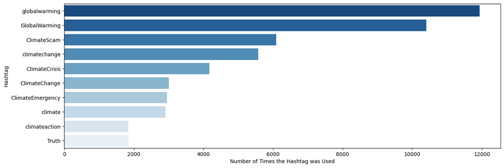

```python
plt.figure(figsize=(15 ,5))

hshtg = sns.barplot(data=topTags, y='Hashtags',x="count", orient='h', palette='Blues_r')

hshtg.set_xlabel( "Number of Times the Hashtag was Used")
hshtg.set_ylabel( "Hashtag")
```

As you can see the top hashtags contain word and phrases like globalwarming, climatechange, climate, climateaction, and even climateEmergency. These terms are very reelvant to the overall topic.

## 7. Who are the top 10 users that have recieved the most mentions? (Spark)

```python
df.select('author.entities.description.mentions').printSchema()
```

```
root
 |-- mentions: array (nullable = true)
 |    |-- element: struct (containsNull = true)
 |    |    |-- end: long (nullable = true)
 |    |    |-- start: long (nullable = true)
 |    |    |-- username: string (nullable = true)
```

```python
df1=df.select('author.username', F.col('author.entities.description.mentions.username').alias('mentions')).filter(F.col('mentions').isNotNull())

df2=df1.select('username', F.explode('mentions').alias('mentions'))
df2.show()
```

```
+---------------+---------------+
|       username|       mentions|
+---------------+---------------+
|  SueMasonBurns|jayjayjjetplane|
|     thebeachll|     DAlSlESSSS|
|brucecharityorg|    BrucewilzUg|
|   gabi_spilker|  EXCInequality|
|   gabi_spilker|    UniKonstanz|
|       tribblez|       theauxdj|
| JavidGillaniMH|  muslimhandspk|
|   AngryGustavo|   Polandballbr|
|  dwallacewells|     nytopinion|
|  dwallacewells|         NYTmag|
| WillKochtitzky|      unetweets|
|      AbeeraMR_|       sosart90|
|          Tyrnn|  BoomerExpress|
|   sapnadeora93|   digvijaya_28|
|   sapnadeora93|     KapilSibal|
|  JacobsOSeaman|   DailyMonitor|
|DiamondGBraxton|   bestmicrofic|
|DiamondGBraxton|   forge_litmag|
|DiamondGBraxton|     defunktmag|
|DiamondGBraxton|        txstmfa|
+---------------+---------------+
only showing top 20 rows
```

```python
df2.groupBy('mentions').count().orderBy(F.desc('count')).show()
```

```
[Stage 202:=================================================>     (58 + 6) / 64]
```

```
+---------------+-----+
|       mentions|count|
+---------------+-----+
|      P4LOIndia| 1033|
|           PTLB|  730|
|   PTLBProjects|  619|
|        TeleLaw|  488|
|  WeMeanToClean|  360|
|     PHRFCIndia|  153|
|       elonmusk|  100|
|  GretaThunberg|  100|
|   RiseUpMovDRC|   89|
|             UN|   88|
|SOCIAL_ISSUES_6|   87|
|GLOBAL_ISSUES_6|   86|
|         318ppm|   79|
|         Wxdude|   69|
|    BeddoeRoger|   64|
|realDonaldTrump|   60|
|           UofT|   59|
|           SDPI|   52|
|     _Perry4Law|   52|
|      RCGS_SGRC|   52|
+---------------+-----+
only showing top 20 rows
```

```python
mntd=df2.groupBy('mentions').count().orderBy(F.desc('count')).limit(10).toPandas()
```

```python
mntd.head(10)
```

|  | mentions | count |
| --- | --- | --- |
| 0 | P4LOIndia | 1033 |
| 1 | PTLB | 730 |
| 2 | PTLBProjects | 619 |
| 3 | TeleLaw | 488 |
| 4 | WeMeanToClean | 360 |
| 5 | PHRFCIndia | 153 |
| 6 | elonmusk | 100 |
| 7 | GretaThunberg | 100 |
| 8 | RiseUpMovDRC | 89 |
| 9 | UN | 88 |

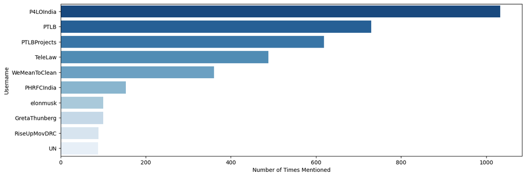

```python
plt.figure(figsize=(15 ,5))

mentioned = sns.barplot(data=mntd, y='mentions',x="count", orient='h', palette='Blues_r')

mentioned.set_xlabel( "Number of Times Mentioned")
mentioned.set_ylabel( "Username")
```

```python
df.select('author.created_at').printSchema()
```

```
root
 |-- created_at: string (nullable = true)
```

```python
df.select('author.created_at','author.public_metrics.tweet_count').orderBy(F.desc('tweet_count')).show()
```

```
[Stage 1:===================================================>     (58 + 6) / 64]
```

```
+--------------------+-----------+
|          created_at|tweet_count|
+--------------------+-----------+
|2013-01-24T09:29:...|    7223844|
|2013-01-24T09:29:...|    7223844|
|2011-04-02T01:01:...|    4488686|
|2013-02-14T16:39:...|    3674417|
|2013-02-14T16:39:...|    3674417|
|2010-04-20T00:22:...|    3226546|
|2010-04-20T00:22:...|    3226546|
|2010-04-20T00:22:...|    3226532|
|2010-03-21T23:23:...|    3143724|
|2010-02-11T17:29:...|    2919106|
|2010-02-11T17:29:...|    2919068|
|2010-02-11T17:29:...|    2919048|
|2009-03-06T03:50:...|    2807640|
|2009-03-06T03:50:...|    2807625|
|2009-11-07T23:18:...|    2702936|
|2012-09-20T03:25:...|    2573678|
|2012-09-20T03:25:...|    2573652|
|2012-09-20T03:25:...|    2573652|
|2012-09-20T03:25:...|    2573652|
|2012-09-20T03:25:...|    2573652|
+--------------------+-----------+
only showing top 20 rows
```

```python
twtdate=df.select('author.created_at','author.public_metrics.tweet_count').orderBy(F.desc('tweet_count')).limit(20).toPandas()
twtdate.head()
```

|  | created_at | tweet_count |
| --- | --- | --- |
| 0 | 2013-01-24T09:29:44.000Z | 7223844 |
| 1 | 2013-01-24T09:29:44.000Z | 7223844 |
| 2 | 2011-04-02T01:01:28.000Z | 4488686 |
| 3 | 2013-02-14T16:39:18.000Z | 3674417 |
| 4 | 2013-02-14T16:39:18.000Z | 3674417 |

```python
twtdate1=twtdate.drop_duplicates(subset='created_at')
twtdate1.head(10)
```

|  | created_at | tweet_count |
| --- | --- | --- |
| 0 | 2013-01-24T09:29:44.000Z | 7223844 |
| 2 | 2011-04-02T01:01:28.000Z | 4488686 |
| 3 | 2013-02-14T16:39:18.000Z | 3674417 |
| 5 | 2010-04-20T00:22:15.000Z | 3226546 |
| 8 | 2010-03-21T23:23:44.000Z | 3143724 |
| 9 | 2010-02-11T17:29:51.000Z | 2919106 |
| 12 | 2009-03-06T03:50:18.000Z | 2807640 |
| 14 | 2009-11-07T23:18:17.000Z | 2702936 |
| 15 | 2012-09-20T03:25:51.000Z | 2573678 |

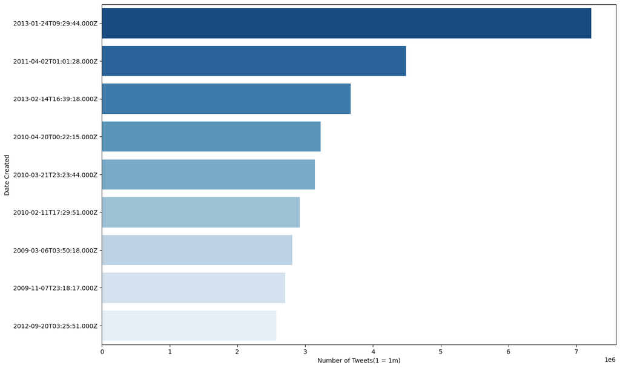

```python
plt.figure(figsize=(15 ,10))

twtdateplot = sns.barplot(data=twtdate1, y='created_at',x="tweet_count", orient='h', palette='Blues_r')

twtdateplot.set_xlabel( "Number of Tweets(1 = 1m)")
twtdateplot.set_ylabel( "Date Created")
```

## 9. How many males and females does the algorithm say there are in the global warming twitter dataset? (Spark)

```python
gndrlist={'male':'male','mostly_male':'male','female':'female','mostly_female':'female','unknown':'unknown'}
```

```python
df.groupby('gender').count().orderBy(F.desc('gender')).where(F.col('gender') != 'andy').show()
```

```
[Stage 23:===>                                                    (4 + 60) / 64]
```

```
+-------------+------+
|       gender| count|
+-------------+------+
|      unknown|176125|
|  mostly_male|  8714|
|mostly_female|  8964|
|         male|103054|
|       female| 42744|
+-------------+------+
```

```python
gender=df.groupby('gender').count().orderBy(F.desc('gender')).where(F.col('gender') != 'andy').toPandas()
```

```python
gender['gender'] = gender['gender'].replace(gndrlist)
gender.head()
```

|  | gender | count |
| --- | --- | --- |
| 0 | unknown | 176125 |
| 1 | male | 8714 |
| 2 | female | 8964 |
| 3 | male | 103054 |
| 4 | female | 42744 |

```python
gender1=gender.groupby('gender', as_index=False)['count'].sum()
gender1.head()
```

|  | gender | count |
| --- | --- | --- |
| 0 | female | 51708 |
| 1 | male | 111768 |
| 2 | unknown | 176125 |

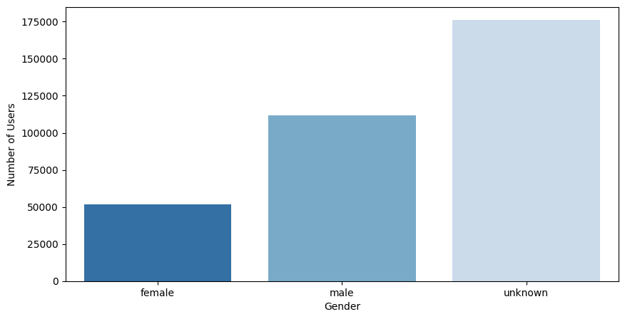

```python
plt.figure(figsize=(10 ,5))

genderplot = sns.barplot(data=gender1, y='count',x="gender", orient='v', palette='Blues_r')

genderplot.set_xlabel( "Gender")
genderplot.set_ylabel( "Number of Users")
```

We can see that there are a lot of users that the algorithm identified as unknown. However, if you compare the number of user that are male vs female the amount of males are a little bit more than double.

## 10. Who are the top 5 users with angry tweets that have the highest confidence score? (Spark)

```python
df.select('anger').printSchema()
```

```
root
 |-- anger: string (nullable = true)
```

```python
angr=df.select('author.username','anger').orderBy(F.desc('anger')).limit(5).toPandas()
angr.head()
```

|  | username | anger |
| --- | --- | --- |
| 0 | FeroFeed | 0.9842857 |
| 1 | CuvisLives | 0.9839431 |
| 2 | RaymondRP65 | 0.9837888 |
| 3 | TheMemesArchive | 0.98375547 |
| 4 | CUM_Advisors | 0.9835884 |

```python
angr['anger'] = angr['anger'].astype(float)
angr.sort_values(by='anger', ascending=False)
angr.head()
```

|  | username | anger |
| --- | --- | --- |
| 0 | FeroFeed | 0.984286 |
| 1 | CuvisLives | 0.983943 |
| 2 | RaymondRP65 | 0.983789 |
| 3 | TheMemesArchive | 0.983755 |
| 4 | CUM_Advisors | 0.983588 |

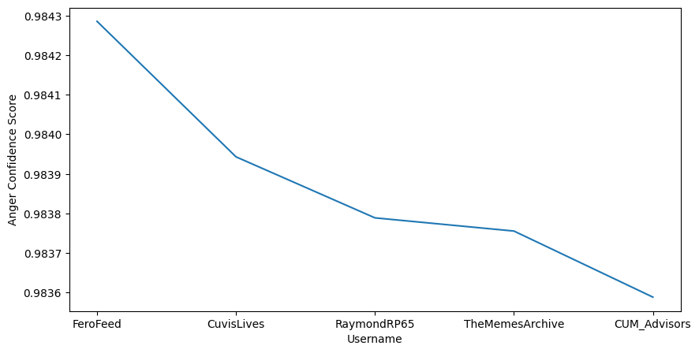

```python
plt.figure(figsize=(10 ,5))

angr1 = sns.lineplot(data=angr, y='anger',x="username", orient='y', palette='Blues_r')

angr1.set_xlabel( "Username")
angr1.set_ylabel( "Anger Confidence Score")
```

As you can see these are the top 5 users based on the confidence of thier tweet being angry.